# IE582-Homework5

Hazal Hasret Yurdakul

07 January 2019

In this assignment, we are given a dataset, namely Musk1.It describes a set of 92 molecules of which 47 are judged by human experts to be musks and the remaining 45 molecules are judged to be non-musks. The goal is to learn to predict whether new molecules will be musks or non-musks.In the fist place, column names are given and features are scaled.

We should determine optimal number of clusters for k-means clustering and hierarchical clustering. “fviz_nbclust” function is used to determine cluster numbe and there are 3 methods, “silhouette”,“wss” and “gap_stat”, used by function. I chose to use “silhouette” method. Silhouette approach measures the quality of a clustering. That is,it determines how well each object lies within its cluster. A high average silhouette width indicates a good clustering.Also,“manhattan” and “euclidean” are proposed as distance measures.For each distance measure alternative,the performance of two clustering approaches,k-means and hierarchical clusterin, are evaluated regarding the area under the ROC curve (AUC) performance based on 10-fold cross-validation on the training data.Since we are asked to work with distances, a modified version of k-means which is called the k-medoids approach is used with pam package.

**Option1 : Kmedoids with Euclidean Distance**

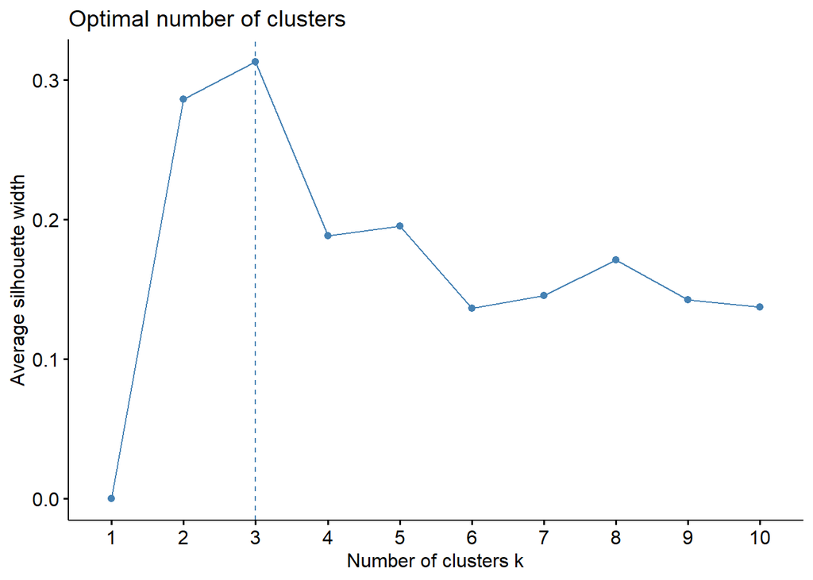

```r
x = my_data[3:ncol(my_data)]

fviz_nbclust(x, FUN = kmeans, method = "silhouette", diss = dist(x,
    method = "euclidean"))
```

```r
## says that optimal number of clusters=3
```

Lasso logistic regression is trained to classify bags. Lasso penalized regression model is performed using “penalized” packgae.optL1 function providesthe best lambda value between minlambda and maxlambda paramaters. 10-fold cross validation is performed to choose the best lambda value.Threshold value is chosen as 0.5 and each instance is classified.10-fold-cross validation is done and area under ROC curve is summarized as:

```r
mean(auc_cv)
```

```
## [1] 0.67
```

**Option2 : Kmedoids with Manhattan Distance**

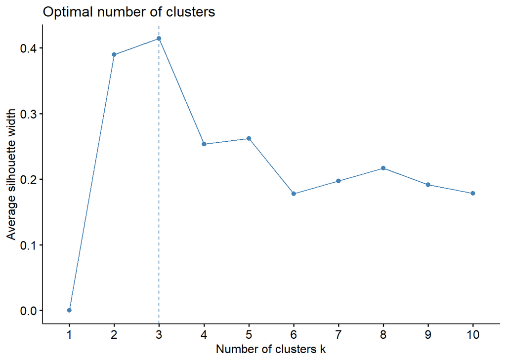

```r
x = my_data[3:ncol(my_data)]

fviz_nbclust(x, FUN = kmeans, method = "silhouette", diss = dist(x,
    method = "manhattan"))
```

```r
mean(auc_cv)
```

```
## [1] 0.7625
```

**Option3 : Hierarchical Clustering with Euclidean Distance**

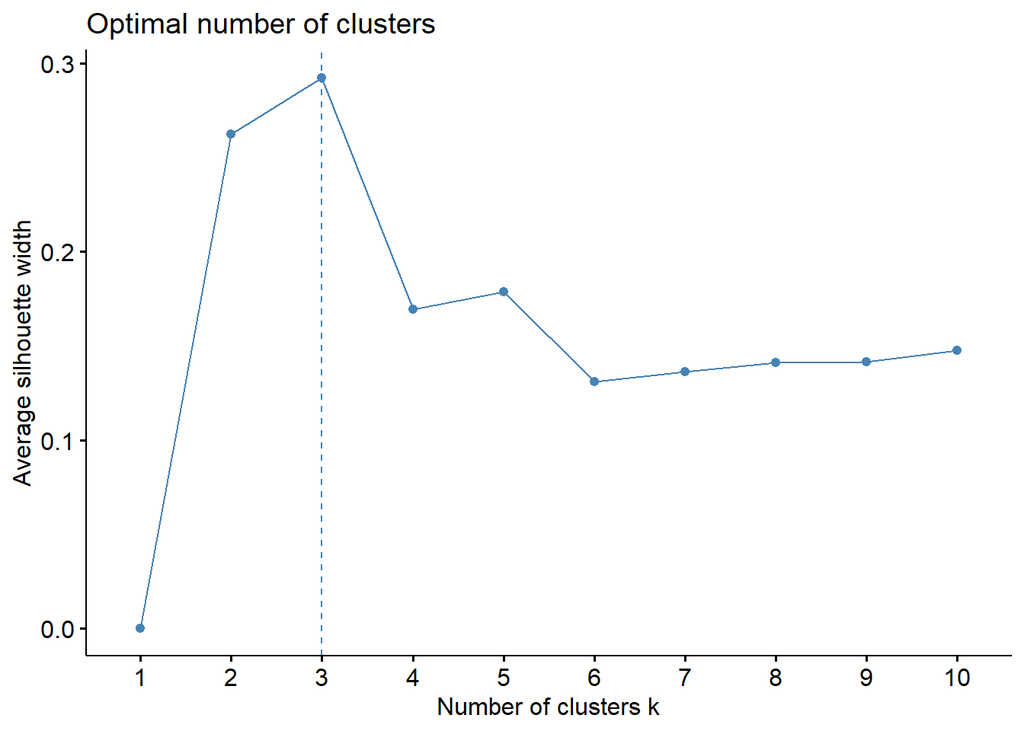

```r
x = my_data[3:ncol(my_data)]

fviz_nbclust(x, FUN = hcut, method = "silhouette", diss = dist(x,
    method = "euclidean"))
```

```r
mean(auc_cv)
```

```
## [1] 0.68
```

**Option4 : Hierarchical Clustering with Manhattan Distance**

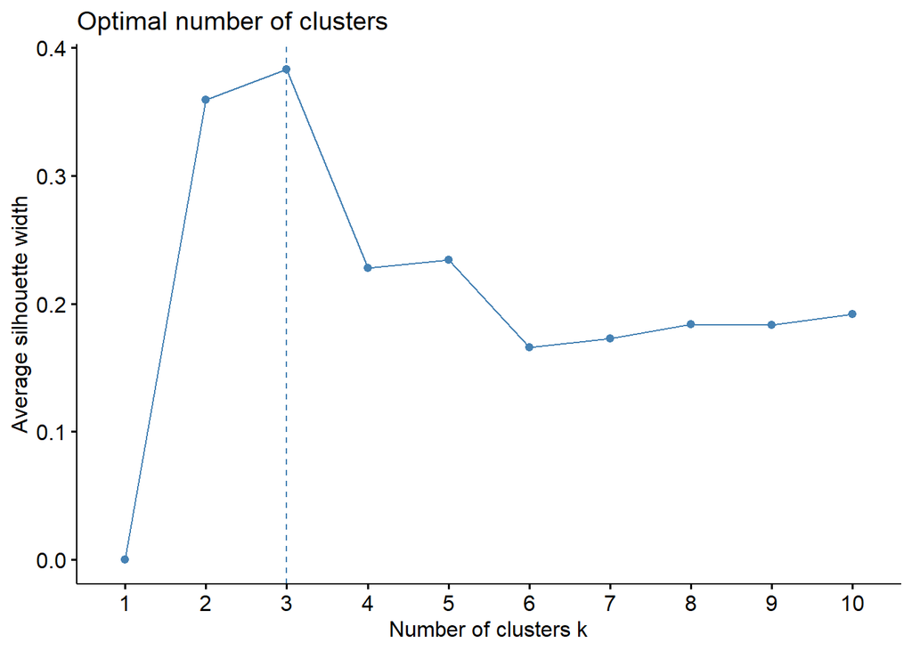

```r
x = my_data[3:ncol(my_data)]
fviz_nbclust(x, FUN = hcut, method = "silhouette", diss = dist(x,
    method = "manhattan"))
```

```r
mean(auc_cv)
```

```
## [1] 0.7325
```

As a result,kmedoids clustering method with manhattan distance has the highest AUC ratio which means it differs the clusters best among 4 methods.

**APPENDIX**

```r
#
library(TunePareto)
library(cluster)
library(factoextra)
library(data.table)
library(dplyr)
library(penalized)
library(pROC)
library(caret)
library(ggplot2)

set.seed(123)

muskdata=read.csv("Musk1.csv",header = FALSE)

columnnames=rep(NA,166)
for(i in 1:166)
{
  columnnames[i]=paste0("Feature",i)
}
colnames(muskdata)=c("bagclass","bagId",columnnames)
features=muskdata[,3:ncol(muskdata)]

scaled_features=scale(features)
scaled_features=data.frame(scaled_features)
my_data=cbind(muskdata$bagclass,muskdata$bagId,scaled_features)

**Option1 : Kmedoids with Euclidean Distance**

x=my_data[3:ncol(my_data)]

fviz_nbclust(x,FUN=kmeans,method="silhouette",diss=dist(x,method="euclidean"))
## says that optimal number of clusters=3

#Step 1: Instances are clustered with clustering algorithm.
#clusters
kmed.euc=pam(x,3,metric="euclidean",stand=FALSE)
cluster=kmed.euc$clustering
cluster

##instances are clustered
muskdata.cluster=cbind(my_data,cluster)

#cluster centers
cluster_center=kmed.euc$medoids
cluster_center=data.table(cluster_center)

#Step 2: The distance of its instances to each cluster centroid are calculated for each bag.
clusterdist = matrix(NA,nrow(my_data[3:ncol(my_data)]),nrow(cluster_center))
for(k in 1:nrow(cluster_center))
{
  for(i in 1:nrow(my_data[3:ncol(my_data)]))
  {
    x=as.vector(my_data[3:ncol(my_data)][i,])
    y=as.vector(cluster_center[k,])
    clusterdist[i,k]=dist(rbind(x, y), method = "euclidean")
  }
}

mydata_dist=cbind(my_data[,1:2],clusterdist)
colnames(mydata_dist)=c("bagclass","bagId","Dist1","Dist2","Dist3")
str(mydata_dist)
head(mydata_dist,5)

#Step 3: Each bag is represented as the average of its instance distances to the cluster centroids.
bag_ave=aggregate(mydata_dist,list(mydata_dist$bagId),mean)
bag_ave_level=bag_ave[2:ncol(bag_ave)]
colnames(bag_ave_level)=c("bagclass","bagId","AvgDist1","AvgDist2","AvgDist3")
head(bag_ave_level,5)

traindata = bag_ave_level[, 3:ncol(bag_ave_level)]
train.class = bag_ave_level$bagclass

lambda1 <- optL1(train.class, penalized = ~., data = traindata,
                 fusedl = FALSE, minlambda1 = 0, maxlambda1 = 2, model = "logistic",
                 fold = 10)

pen <- penalized(train.class, penalized = ~., data = traindata,
                 lambda1 = lambda1$lambda, model = "logistic", fusedl = FALSE)

prediction = predict(pen, penalized = traindata)

for (i in 1:length(prediction)) {
  if (prediction[i] < 0.5) {
    prediction[i] = 0
  } else {
    prediction[i] = 1
  }
}

set.seed(123)

fold_indices=generateCVRuns(as.factor(train.class),1,10,stratified=TRUE)
auc_cv<-rep(NA,10)
traindata_withclass=cbind(train.class,traindata)

for (i in 1:10) {
  Replication=fold_indices[[1]]
  testindices=Replication[[i]]
  train=traindata_withclass[-testindices,]
  test=traindata_withclass[testindices,]
  train_class<-train$train.class

  prediction=predict(pen,penalized=test[,2:4])

  for (k in 1:length(prediction)) {
    if (prediction[k] < 0.5) {
      prediction[k] = 0
    } else {
      prediction[k] = 1
    }
  }

  roc_obj <- roc(test$train.class, prediction)
  auc_cv[i] = auc(roc_obj)
}
mean(auc_cv)
```

```r
# **Option2 : Kmedoids with Manhattan Distance**
x = my_data[3:ncol(my_data)]

fviz_nbclust(x, FUN = kmeans, method = "silhouette", diss = dist(x,
    method = "manhattan"))
kmed.euc = pam(x, 3, metric = "manhattan", stand = FALSE)

# clusters
cluster = kmed.euc$clustering
cluster

## instances are clustered
muskdata.cluster = cbind(my_data, cluster)

# cluster centers
cluster_center = kmed.euc$medoids
cluster_center = data.table(cluster_center)

# Calculate the distance of its instances to each cluster
# centroid

clusterdist = matrix(NA, nrow(my_data[3:ncol(my_data)]), nrow(cluster_center))
for (k in 1:nrow(cluster_center)) {
    for (i in 1:nrow(my_data[3:ncol(my_data)])) {
        x = as.vector(my_data[3:ncol(my_data)][i, ])
        y = as.vector(cluster_center[k, ])
        clusterdist[i, k] = dist(rbind(x, y), method = "manhattan")
    }
}



mydata_dist = cbind(my_data[, 1:2], clusterdist)
colnames(mydata_dist) = c("bagclass", "bagId", "Dist1", "Dist2",
    "Dist3")
str(mydata_dist)
head(mydata_dist, 5)

# Represent the bag as the average of its instance distances
# to the cluster centroids
bag_ave = aggregate(mydata_dist, list(mydata_dist$bagId), mean)
bag_ave_level = bag_ave[2:ncol(bag_ave)]
colnames(bag_ave_level) = c("bagclass", "bagId", "AvgDist1",
    "AvgDist2", "AvgDist3")
head(bag_ave_level, 5)


## train lasso logistic regression to classify bags
traindata = bag_ave_level[, 3:ncol(bag_ave_level)]
train.class = bag_ave_level$bagclass

lambda1 <- optL1(train.class, penalized = ~., data = traindata,
    fusedl = FALSE, minlambda1 = 0, maxlambda1 = 2, model = "logistic",
    fold = 10)

pen <- penalized(train.class, penalized = ~., data = traindata,
    lambda1 = lambda1$lambda, model = "logistic", fusedl = FALSE)

prediction = predict(pen, penalized = traindata)
roc_obj <- roc(train.class, prediction)
auc(roc_obj)
ggroc(roc_obj, alpha = 0.5, colour = "red", linetype = 1, size = 2)

for (i in 1:length(prediction)) {
    if (prediction[i] < 0.5) {
        prediction[i] = 0
    } else {
        prediction[i] = 1
    }
}

set.seed(123)
fold_indices = generateCVRuns(as.factor(train.class), 1, 10,
    stratified = TRUE)
auc_cv <- rep(NA, 10)
traindata_withclass = cbind(train.class, traindata)

for (i in 1:10) {
    Replication = fold_indices[[1]]
    testindices = Replication[[i]]
    train = traindata_withclass[-testindices, ]
    test = traindata_withclass[testindices, ]
    train_class <- train$train.class

    prediction = predict(pen, penalized = test[, 2:4])

    for (k in 1:length(prediction)) {
        if (prediction[k] < 0.5) {
            prediction[k] = 0
        } else {
            prediction[k] = 1
        }
    }

    roc_obj <- roc(test$train.class, prediction)
    auc_cv[i] = auc(roc_obj)
}

mean(auc_cv)
```

```r
# **Option3 : Hierarchical Clustering with Euclidean
# Distance**
x = my_data[3:ncol(my_data)]

fviz_nbclust(x, FUN = hcut, method = "silhouette", diss = dist(x,
    method = "euclidean"))

## says that optimal number of clusters=3

clusters = cutree(hclust(dist(x, method = "euclidean")), k = 3)

# function to find medoid in cluster i
clust.centroid = function(i, dat, clusters) {
    ind = (clusters == i)
    colMeans(dat[ind, ])
}

# clusters
cluster = clusters
cluster

## instances are clustered
muskdata.cluster = cbind(my_data, cluster)

# cluster centers
cluster_center = t(sapply(unique(clusters), clust.centroid, x,
    clusters))
cluster_center = data.table(cluster_center)

# Calculate the distance of its instances to each cluster
# centroid

clusterdist = matrix(NA, nrow(my_data[3:ncol(my_data)]), nrow(cluster_center))
for (k in 1:nrow(cluster_center)) {
    for (i in 1:nrow(my_data[3:ncol(my_data)])) {
        x = as.vector(my_data[3:ncol(my_data)][i, ])
        y = as.vector(cluster_center[k, ])
        clusterdist[i, k] = dist(rbind(x, y), method = "euclidean")
    }
}


mydata_dist = cbind(my_data[, 1:2], clusterdist)
colnames(mydata_dist) = c("bagclass", "bagId", "Dist1", "Dist2",
    "Dist3")
str(mydata_dist)
head(mydata_dist, 5)

# Represent the bag as the average of its instance distances
# to the cluster centroids
bag_ave = aggregate(mydata_dist, list(mydata_dist$bagId), mean)
bag_ave_level = bag_ave[2:ncol(bag_ave)]
colnames(bag_ave_level) = c("bagclass", "bagId", "AvgDist1",
    "AvgDist2", "AvgDist3")
head(bag_ave_level, 5)


## train lasso logistic regression to classify bags
traindata = bag_ave_level[, 3:ncol(bag_ave_level)]
train.class = bag_ave_level$bagclass

lambda1 <- optL1(train.class, penalized = ~., data = traindata,
    fusedl = FALSE, minlambda1 = 0, maxlambda1 = 2, model = "logistic",
    fold = 10)

pen <- penalized(train.class, penalized = ~., data = traindata,
    lambda1 = lambda1$lambda, model = "logistic", fusedl = FALSE)

prediction = predict(pen, penalized = traindata)

for (i in 1:length(prediction)) {
    if (prediction[i] < 0.5) {
        prediction[i] = 0
    } else {
        prediction[i] = 1
    }
}

roc_obj <- roc(train.class, prediction)
auc(roc_obj)
ggroc(roc_obj, alpha = 0.5, colour = "red", linetype = 1, size = 2)

set.seed(123)
fold_indices = generateCVRuns(as.factor(train.class), 1, 10,
    stratified = TRUE)
auc_cv <- rep(NA, 10)
traindata_withclass = cbind(train.class, traindata)

for (i in 1:10) {
    Replication = fold_indices[[1]]
    testindices = Replication[[i]]
    train = traindata_withclass[-testindices, ]
    test = traindata_withclass[testindices, ]
    train_class <- train$train.class

    prediction = predict(pen, penalized = test[, 2:4])

    for (k in 1:length(prediction)) {
        if (prediction[k] < 0.5) {
            prediction[k] = 0
        } else {
            prediction[k] = 1
        }
    }

    roc_obj <- roc(test$train.class, prediction)
    auc_cv[i] = auc(roc_obj)
}

mean(auc_cv)
```

```r
# **Option4 : Hierarchical Clustering with Manhattan
# Distance**
x = my_data[3:ncol(my_data)]
fviz_nbclust(x, FUN = hcut, method = "silhouette", diss = dist(x,
    method = "manhattan"))
## says that optimal number of clusters=3

clusters = cutree(hclust(dist(x, method = "manhattan")), k = 3)

# function to find medoid in cluster i
clust.centroid = function(i, dat, clusters) {
    ind = (clusters == i)
    colMeans(dat[ind, ])
}

# clusters
cluster = clusters
cluster

## instances are clustered
muskdata.cluster = cbind(my_data, cluster)

# cluster centers
cluster_center = t(sapply(unique(clusters), clust.centroid, x,
    clusters))
cluster_center = data.table(cluster_center)

# Calculate the distance of its instances to each cluster
# centroid

clusterdist = matrix(NA, nrow(my_data[3:ncol(my_data)]), nrow(cluster_center))
for (k in 1:nrow(cluster_center)) {
    for (i in 1:nrow(my_data[3:ncol(my_data)])) {
        x = as.vector(my_data[3:ncol(my_data)][i, ])
        y = as.vector(cluster_center[k, ])
        clusterdist[i, k] = dist(rbind(x, y), method = "manhattan")
    }
}


mydata_dist = cbind(my_data[, 1:2], clusterdist)

colnames(mydata_dist) = c("bagclass", "bagId", "Dist1", "Dist2",
    "Dist3")
str(mydata_dist)
head(mydata_dist, 5)

# Represent the bag as the average of its instance distances
# to the cluster centroids

bag_ave = aggregate(mydata_dist, list(mydata_dist$bagId), mean)
bag_ave_level = bag_ave[2:ncol(bag_ave)]
colnames(bag_ave_level) = c("bagclass", "bagId", "AvgDist1",
    "AvgDist2", "AvgDist3")
head(bag_ave_level, 5)

# train lasso logistic regression to classify bags
traindata = bag_ave_level[, 3:ncol(bag_ave_level)]
train.class = bag_ave_level$bagclass

lambda1 <- optL1(train.class, penalized = ~., data = traindata,
    fusedl = FALSE, minlambda1 = 0, maxlambda1 = 2, model = "logistic",
    fold = 10)

pen <- penalized(train.class, penalized = ~., data = traindata,
    lambda1 = lambda1$lambda, model = "logistic", fusedl = FALSE)

prediction = predict(pen, penalized = traindata)

for (i in 1:length(prediction)) {
    if (prediction[i] < 0.5) {
        prediction[i] = 0
    } else {
        prediction[i] = 1
    }
}

roc_obj <- roc(train.class, prediction)
auc(roc_obj)
ggroc(roc_obj, alpha = 0.5, colour = "red", linetype = 1, size = 2)

set.seed(123)
fold_indices = generateCVRuns(as.factor(train.class), 1, 10,
    stratified = TRUE)
auc_cv <- rep(NA, 10)
traindata_withclass = cbind(train.class, traindata)

for (i in 1:10) {
    Replication = fold_indices[[1]]
    testindices = Replication[[i]]
    train = traindata_withclass[-testindices, ]
    test = traindata_withclass[testindices, ]
    train_class <- train$train.class

    prediction = predict(pen, penalized = test[, 2:4])

    for (k in 1:length(prediction)) {
        if (prediction[k] < 0.5) {
            prediction[k] = 0
        } else {
            prediction[k] = 1
        }
    }

    roc_obj <- roc(test$train.class, prediction)
    auc_cv[i] = auc(roc_obj)
}
mean(auc_cv)
```